# Pest control of aphids depends on landscape complexity and natural enemy interactions

Ajobiewe, E., Benedetto, A., Karasawa, M., & Martinez, F.

15/12/2020

Note that the data was provided by the following scientific article: **“Pest control of aphids on landscape complexity and natural enemy interactions”.** It can be retrieved from: https://datadryad.org/stash/dataset/doi:10.5061/dryad.n6428

# Introduction

Aphids are a **major concern** in agricultural crops. Control by natural enemies is an essential component of the ecological intensification of agriculture. This study used multiple natural enemy enclosures replicated in 18 fields of Brassica oleracea and other crop types across a gradient in **landscape complexity** to investigate:the strength of natural pest control across landscapes, the contribution of natural enemy guilds to pest control and the interaction effect between natural enemy guilds and landscape.

In this study, the variables are as follows:

1. **Dependent variables**: Aphid Population Growth (APG), Aphid density, Parasitized Aphids, Parasitism rate, Syrphid larvae, Syrphid fraction, and the real final dependent variable which is final cabbage biomass.
2. **Independent variables**: Landscape complexity, Natural Exclusion Treatments (a combination of one or more natural enemies), Field management, crop type, crop initial maturity, % of seminatural habitat, radius of the buffer, Date.

As of right now, we have assessed the relationships between the following variables:

1. Treatment –> Aphid density/APG
2. Aphid parasitized –> Aphids density/APG
3. Aphids density/APG –> Aphids parasitized
4. Syrphid fraction –> Aphids density
5. Aphids density –> Final Cabbage biomass
6. Field Management –> Aphids density
7. Field Management –> Syrphid fraction
8. Field Management –> Aphids parasitized
9. Crop initial maturity –> Aphids density
10. Crop initial maturity –> Syrphid fraction
11. Crop type –> Aphids density
12. Crop type –> Syrphid fraction
13. % Semi natural habitat –> Aphids density
14. % Semi natural habitat –> Syrphid fraction
15. % Semi natural habitat –> Aphids parasitized
16. % Semi natural habitat –> Final Cabbage Biomass
17. Field Management –> Final Cabbage Biomass
18. Plot ID –> Aphids density
19. Date –> Aphids density
20. Treatment –> Parasitism rate
21. Parasitism rate –> Aphids density
22. Parasitism rate –> APG
23. Syrphid fraction –> APG
24. Crop maturity –> Parasitism rate
25. % Seminatural habitat –> Parasitism rate
26. Field Management –> Parasitism rate

It is pertinent to point out that we have not elucidated the relationships relating Parasitism rate and other variables except for “Parasitism rate ~ Treatment”.

We have represented all possible relationships in the following **network**:

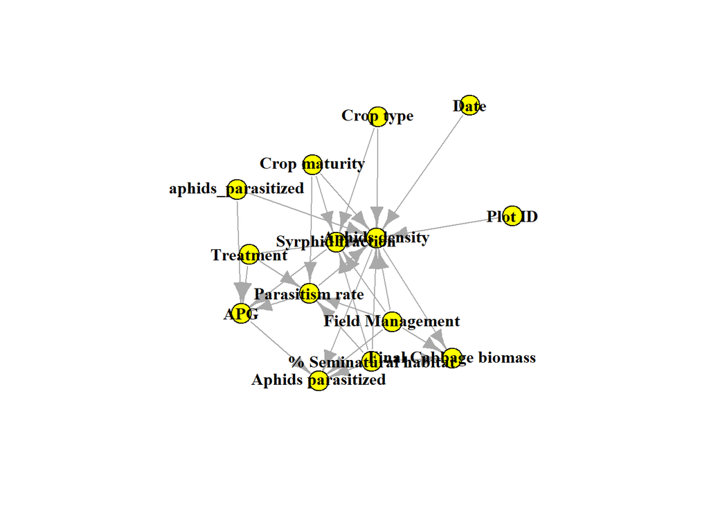

# Objectives.

Our major objectives were to assess:

1. The effect of natural enemies on aphid population growth across a gradient of landscape complexity.
2. The individual and interacting effects of different natural enemy guilds on aphid population growth
3. The possible interaction effect between natural enemy guilds and landscape complexity.

# Hypotheses.

1. We will study whether the presence of natural enemies decrease aphid population growth, comparing plots with NE present to plots where NE is absent. In this case, the null hypothesis is that there is no significant difference in population growth between plots when NE is present and NE is absent.
2. We will study whether the combination of natural enemies have a complementary effect and not an antagonistic effect on aphid population growth.
3. We will study whether the effect of natural enemies is stronger in complex landscapes, comparing plots with complex landscapes to plots with simplified ones.
4. We will study whether there is an interaction effect between the type of NE and landscape complexity. According to the null hypothesis, the interaction may not be significant. If it is rejected, it would probably mean that we will see some guilds perform better in some landscape than others.
5. We will study if the parasitism rate and syrphid fraction increases with landscape complexity or not. (H0; No differences in parasitism rate and syrphid fraction in complex landscapes )
6. We will study whether aphid growth population decreases cabbage biomass (null hypothesis: no significant differences)..

# Methods.

Step by Step:

1. We assessed the relationships between multiple variables (excluding Parasitism rate for which we only did "Parasitism rate ~ Treatment) using a linear model (lm).
2. We compared “direct relationships” between 2 variables and relationships between two variables with an interaction effect involving a third variable using the AIC function. We were hoping to detect significant interaction effects. To determine whether the two models were significantly different from each other, we used the Anova test.
3. We plotted several graphs with new variables such as APG, Syrphid fraction and Paratism rate.
4. We started to compare the different models that rely on a different set of variables using the AIC function. However, the values strayed away from the ones reported in the article. Different models other than lm will have to be tested.

# Results

#### **Map of the Treatment plots**

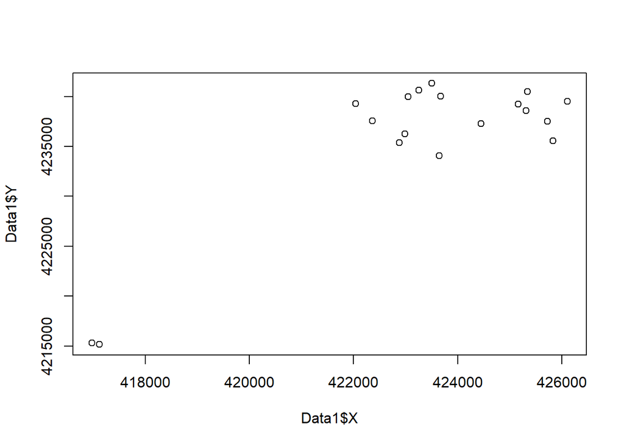

```r
Data1 <- read.table("Project data.csv", header = TRUE, dec = ",", sep = ";")
plot(Data1$X, Data1$Y)
```

##### **Remark**: We did not include the sequence of linear models (lms) here. They can all be found in the “data folder” in a document called “Linear models 1-20”.

#### **Effects of landscape complexity and natural enemy exclusion on average daily aphid population growth across three sampling dates (1-3).**

APG: APhids population growth  
LC: Landscape complexity

```r
#import data file
library(readr)
Data1 <- read.table("Project data.csv", header = TRUE, dec = ",", sep =";")

###dataframe for sampling date1
DATE1 <- Data1[Data1$Date == "1", ]
DATE1_700 <- subset(DATE1, DATE1$BUFF_DIST == "700")
```

#### **Bar graph for APG**

##### **Date1**

```r
#calculate the aphids population growth at date1
logNaphids_D1_bar <- log(DATE1$aphid_live+1) - log(DATE1$aphidsinoculated_init+1)
APG_D1_bar <- logNaphids_D1_bar/10
#dataframe for seminatural habitat and aphids population growth at date1
DATE1APG_bar <- data.frame(DATE1,APG_D1_bar)
```

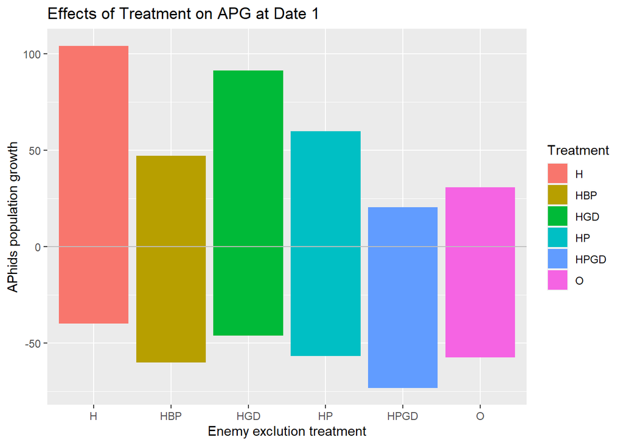

Effects of Treatment on APG at Date 1

```r
#plot
library(ggplot2)
Bar_APGD1 <- ggplot(DATE1APG_bar, aes(x = Treatment, y = APG_D1_bar, fill = Treatment))
Bar_APGD1 <- Bar_APGD1 + geom_bar(stat = "identity")
Bar_APGD1 <- Bar_APGD1 + labs(x= "Enemy exclution treatment", y="APhids population growth", title = "Effects of Treatment on APG at Date 1")
Bar_APGD1 <- Bar_APGD1 + geom_hline(yintercept=0, colour="grey")
#Bar_APGD1 <- Bar_APGD1 + ylim(-0.1 , 0.15)
plot(Bar_APGD1)
```

##### **Date2**

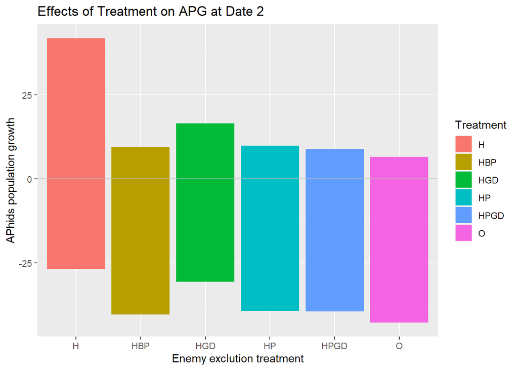

Effects of Treatment on APG at Date 2

```r
####dataframe for sampling date2
DATE2 <- Data1[Data1$Date == "2", ]
DATE2_700 <- subset(DATE2, DATE2$BUFF_DIST == "700")

#Bar graph
#calculate the aphids population growth at date1
logNaphids_D2_bar <- log(DATE2$aphid_live+1) - log(DATE2$aphidsinoculated_init+1)
APG_D2_bar <- logNaphids_D2_bar/20

#dataframe for seminatural habitat and aphids population growth at date1
DATE2APG_bar <- data.frame(DATE2,APG_D2_bar)

#plot
Bar_APGD2 <- ggplot(DATE2APG_bar, aes(x = Treatment, y = APG_D2_bar, fill = Treatment))
Bar_APGD2 <- Bar_APGD2 + geom_bar(stat = "identity")
Bar_APGD2 <- Bar_APGD2 + labs(x= "Enemy exclution treatment", y="APhids population growth", title = "Effects of Treatment on APG at Date 2")
Bar_APGD2 <- Bar_APGD2 + geom_hline(yintercept=0, colour="grey")
plot(Bar_APGD2)
```

##### **Date3**

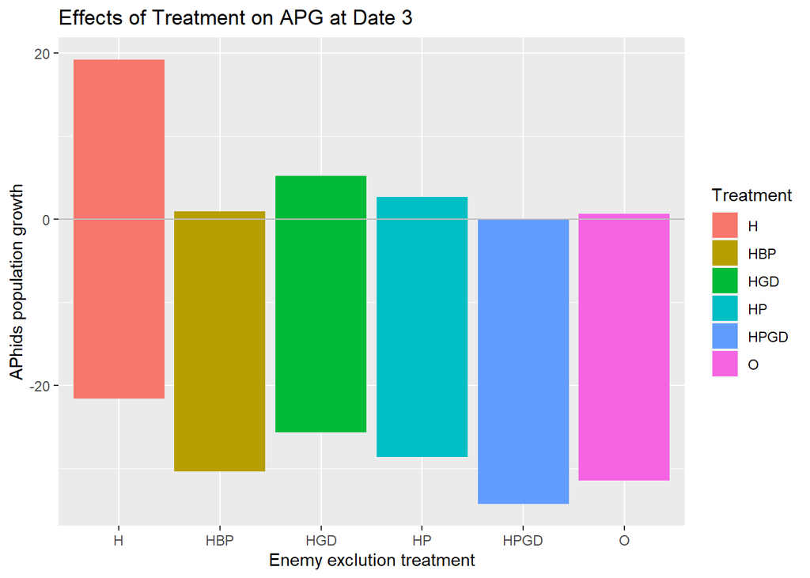

Effects of Treatment on APG at Date 3

```r
####dataframe for sampling date3
DATE3 <- Data1[Data1$Date == "3", ]
DATE3_700 <- subset(DATE3, DATE3$BUFF_DIST == "700")

#calculate the aphids population growth at date1
logNaphids_D3_bar <- log(DATE3$aphid_live+1) - log(DATE3$aphidsinoculated_init+1)
APG_D3_bar <- logNaphids_D3_bar/30

#dataframe for seminatural habitat and aphids population growth at date1
DATE3APG_bar <- data.frame(DATE3,APG_D3_bar)

#plot
Bar_APGD3 <- ggplot(DATE3APG_bar, aes(x = Treatment, y = APG_D3_bar, fill = Treatment))
Bar_APGD3 <- Bar_APGD3 + geom_bar(stat = "identity")
Bar_APGD3 <- Bar_APGD3 + labs(x= "Enemy exclution treatment", y="APhids population growth", title = "Effects of Treatment on APG at Date 3")
Bar_APGD3 <- Bar_APGD3 + geom_hline(yintercept=0, colour="grey")
plot(Bar_APGD3)
```

#### **Line graph for APG**

These lines graphs show the effects of landscape complexity and natural enemy exclusion (NEE) on average daily aphid population growth across three sampling dates (1-3).  
They show the variation of predicted values across the gradient in landscape complexity, measured by percent seminatural habitat in a 700 m radius around fields.

##### **Date 1**

```r
#calculate the aphids population growth at date1
logNaphids_D1_line <- log(DATE1_700$aphid_live+1) - log(DATE1_700$aphidsinoculated_init+1)
APG_D1_line <- logNaphids_D1_line/10
```

```r
#dataframe for seminatural habitat and aphids population growth at date1
DATE1APG_line <- data.frame(DATE1_700,APG_D1_line)
```

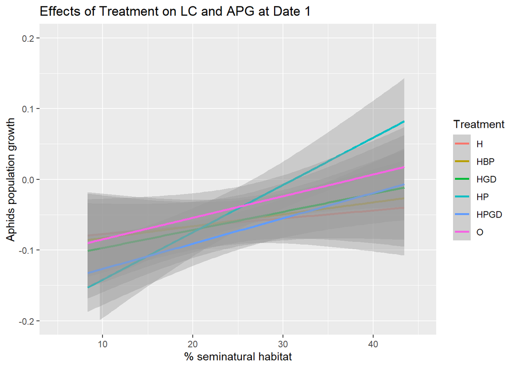

Effects of Treatment on LC and APG at Date 1

```r
#barplot for % Seminatural habitat and APhid population growth
Line_APGD1 <- ggplot(DATE1APG_line, aes(x = Pt.seminatural, y = APG_D1_line, color = Treatment))
Line_APGD1 <- Line_APGD1 + labs(x= "% seminatural habitat", y="Aphids population growth", title = "Effects of Treatment on LC and APG at Date 1")
Line_APGD1 <- Line_APGD1 + geom_smooth(method = "lm")
Line_APGD1 <- Line_APGD1 +xlim(5,45) +ylim(-0.2 , 0.2)
print(Line_APGD1)
```

##### **Date2**

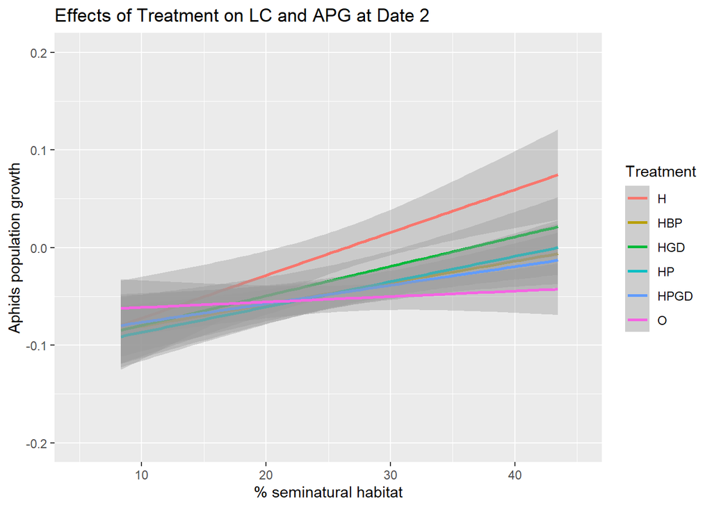

Effects of Treatment on LC and APG at Date 2

```r
#calculate the aphids population growth at date1
logNaphids_D2_line <- log(DATE2_700$aphid_live+1) - log(DATE2_700$aphidsinoculated_init+1)
APG_D2_line <- logNaphids_D2_line/20

#dataframe for seminatural habitat and aphids population growth at date1
DATE2APG_line <- data.frame(DATE2_700,APG_D2_line)

#barplot for % Seminatural habitat and APhid population growth
Line_APGD2 <- ggplot(DATE2APG_line, aes(x = Pt.seminatural, y = APG_D2_line, color = Treatment))
Line_APGD2 <- Line_APGD2 + labs(x= "% seminatural habitat", y="Aphids population growth", title = "Effects of Treatment on LC and APG at Date 2")
# for scatter plot: use geom_point()
Line_APGD2 <- Line_APGD2 + geom_smooth(method = "lm")
Line_APGD2 <- Line_APGD2 +xlim(5,45) +ylim(-0.2 , 0.2)
print(Line_APGD2)
```

##### **Date3**

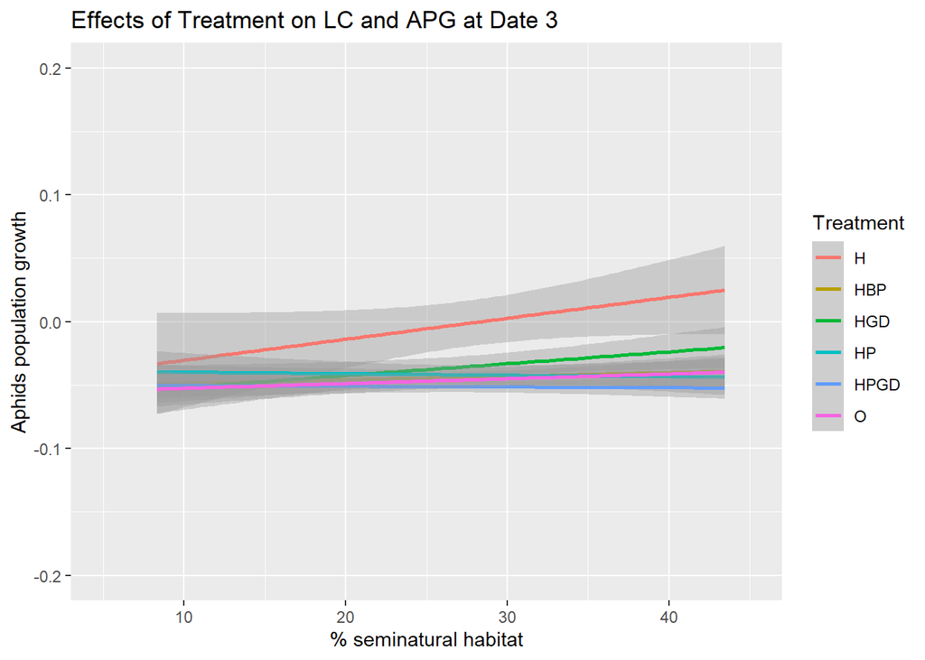

Effects of Treatment on LC and APG at Date 3

```r
#calculate the aphids population growth at date1
logNaphids_D3_line <- log(DATE3_700$aphid_live+1) - log(DATE3_700$aphidsinoculated_init+1)
APG_D3_line <- logNaphids_D3_line/30

#dataframe for seminatural habitat and aphids population growth at date1
DATE3APG_line <- data.frame(DATE3_700,APG_D3_line)

#barplot for % Seminatural habitat and APhid population growth
Line_APGD3 <- ggplot(DATE3APG_line, aes(x = Pt.seminatural, y = APG_D3_line, color = Treatment))
Line_APGD3 <- Line_APGD3 + labs(x= "% seminatural habitat", y="Aphids population growth", title = "Effects of Treatment on LC and APG at Date 3")
# for scatter plot: use geom_point()
Line_APGD3 <- Line_APGD3 + geom_smooth(method = "lm")
Line_APGD3 <- Line_APGD3 +xlim(5,45) +ylim(-0.2 , 0.2)
print(Line_APGD3)
```

#### **Effects of landscape complexity and natural enemy exclusion on aphid parasitism rate at three sampling dates (dates 1–3; 10 day intervals).**

#### **Bar graph for Parasitism rate**

##### **Date1**

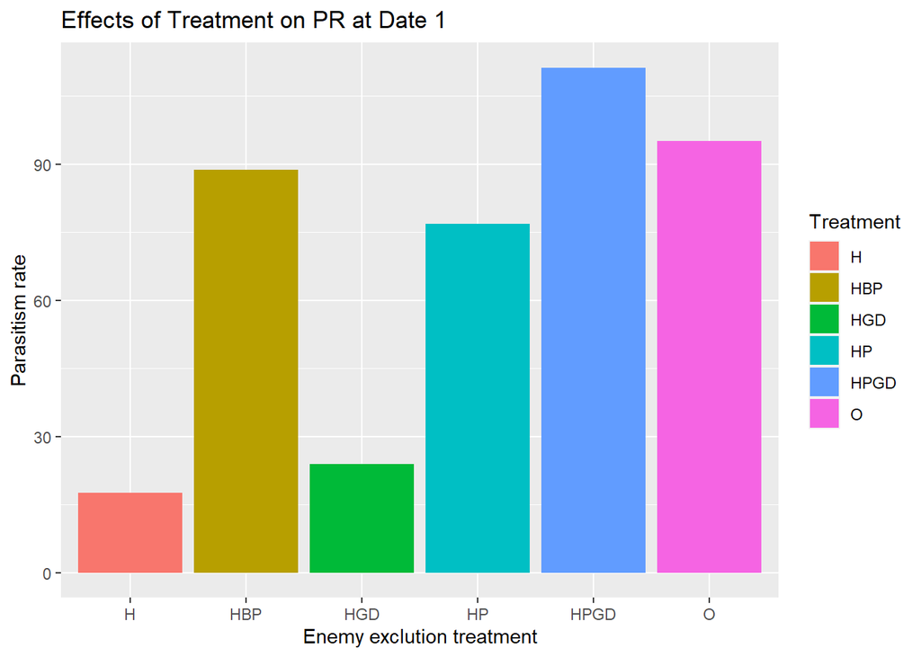

Effects of Treatment on PR at Date 1

```r
#dataframe for sampling date1
DATE1 <- Data1[Data1$Date == "1", ]
DATE1_200 <-  subset(DATE1, DATE1$BUFF_DIST == "200")

# parasitism rate
PR_D1_bar　<- DATE1$aphid_parasitized/(DATE1$aphid_live + DATE1$aphid_parasitized)

#add parasitism rate to the dataframe
DATE1PR_bar <- data.frame(DATE1,PR_D1_bar)

#plot
Bar_PRD1 <- ggplot(DATE1PR_bar, aes(x = Treatment, y = PR_D1_bar, fill = Treatment))
Bar_PRD1 <- Bar_PRD1 + geom_bar(stat = "identity")
Bar_PRD1 <- Bar_PRD1 + labs(x= "Enemy exclution treatment", y="Parasitism rate", title = "Effects of Treatment on PR at Date 1")
plot(Bar_PRD1)
```

##### **Date2**

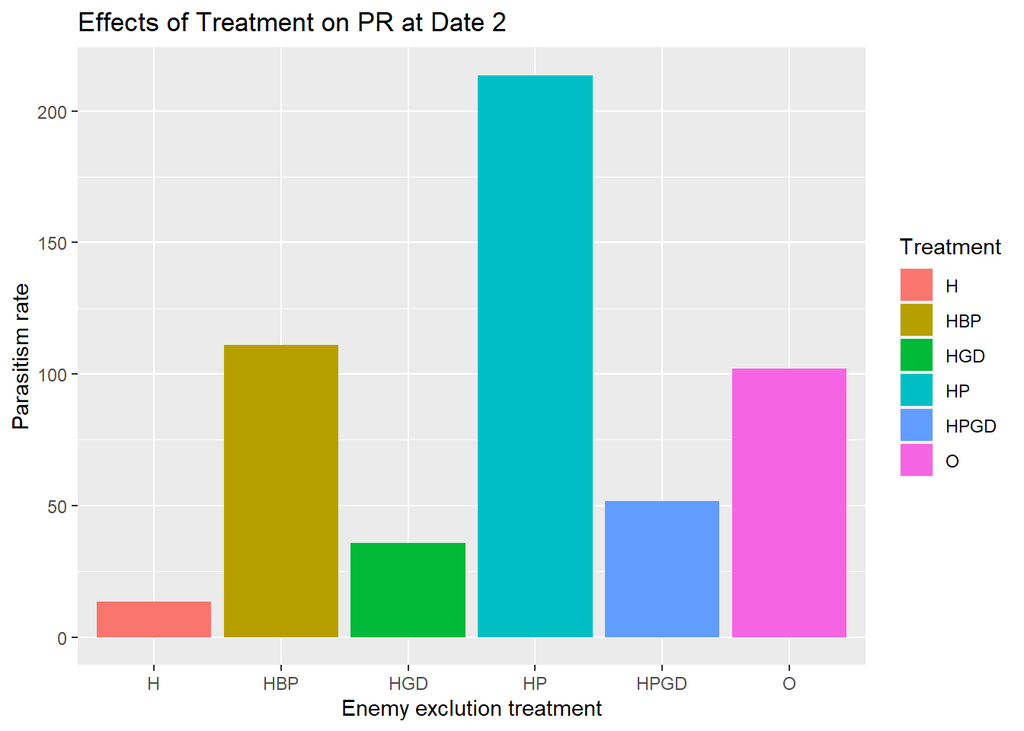

Effects of Treatment on PR at Date 2

```r
# parasitism rate
PR_D2_bar　<- DATE2$aphid_parasitized/(DATE2$aphid_live + DATE2$aphid_parasitized)

#dataframe including PR
DATE2PR_bar <- data.frame(DATE2,PR_D2_bar)

#plot
Bar_PRD2 <- ggplot(DATE2PR_bar, aes(x = Treatment, y = PR_D2_bar, fill = Treatment))
Bar_PRD2 <- Bar_PRD2 + geom_bar(stat = "identity")
Bar_PRD2 <- Bar_PRD2 + labs(x= "Enemy exclution treatment", y="Parasitism rate", title = "Effects of Treatment on PR at Date 2")
plot(Bar_PRD2)
```

##### **Date3**

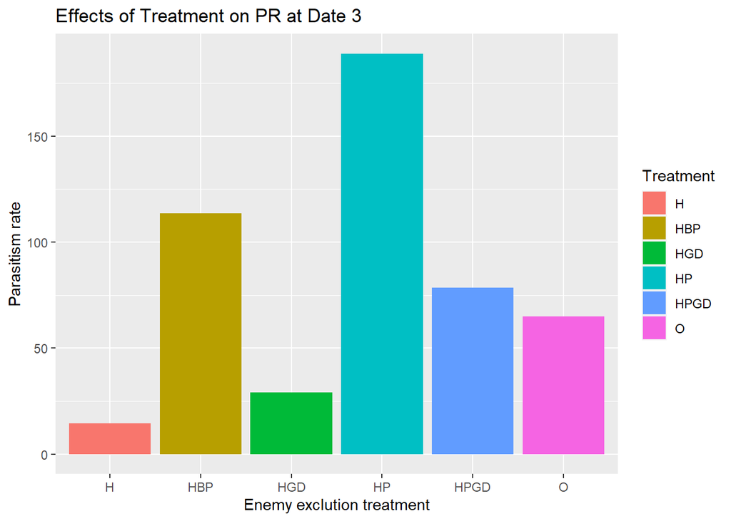

Effects of Treatment on PR at Date 3

```r
# parasitism rate - Treatment
PR_D3_bar　<- DATE3$aphid_parasitized/(DATE3$aphid_live + DATE3$aphid_parasitized)

#dataframe including parasitism rate at date3
DATE3PR_bar <- data.frame(DATE3,PR_D3_bar)

#plot
Bar_PRD3 <- ggplot(DATE3PR_bar, aes(x = Treatment, y = PR_D3_bar, fill = Treatment))
Bar_PRD3 <- Bar_PRD3 + geom_bar(stat = "identity")
Bar_PRD3 <- Bar_PRD3 + labs(x= "Enemy exclution treatment", y="Parasitism rate", title = "Effects of Treatment on PR at Date 3")
plot(Bar_PRD3)
```

#### **Effects of landscape complexity and natural enemy exclusion on syrphid fraction at three sampling dates (dates 1–3; 10 day intervals).**

##### **Date1**

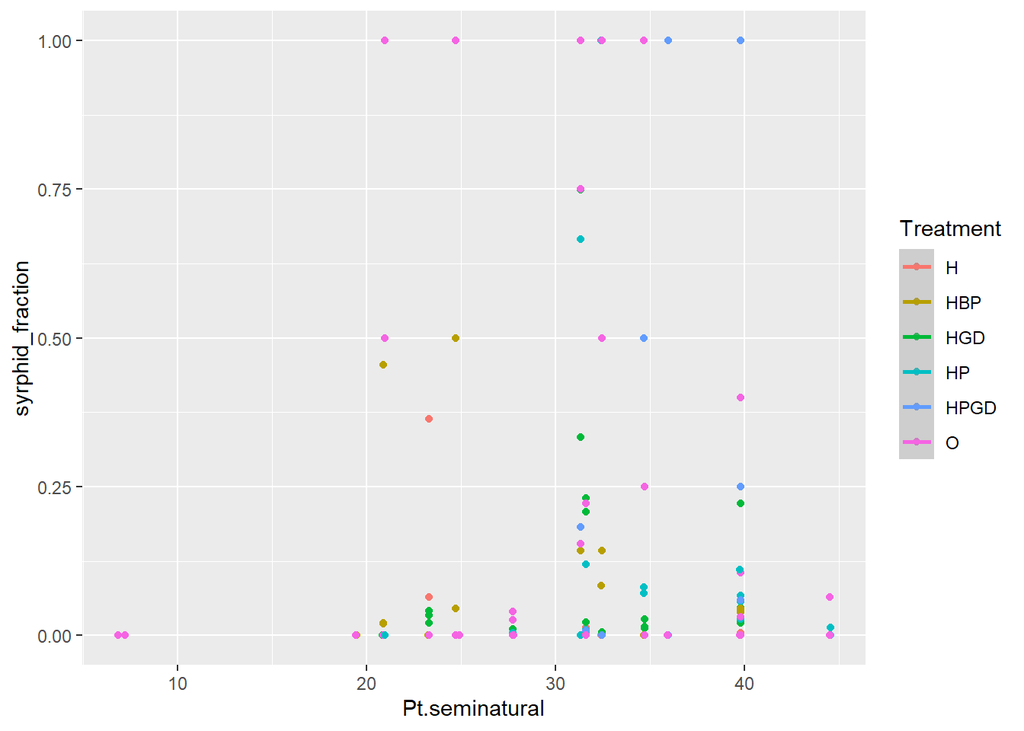

```r
Data1 <- read.table("Project data.csv", header = TRUE, dec = ",", sep =";")
Date_1 <- Data1[Data1$Date == "1", ]
syrphid_fraction <- (Date_1$syrphidl_p /((Date_1$aphid_live)+(Date_1$syrphidl_p)))
Date_1$syrphid_fraction <- syrphid_fraction

Date1buff <- subset(Date_1, BUFF_DIST ==900)

# lm using Date_1
lm1 <- lm(Date1buff$syrphid_fraction ~ Date1buff$Pt.seminatural)

# ggplot using Date1buff
ggplot(Date1buff, aes(x= Pt.seminatural, y= syrphid_fraction,
                   color = Treatment)) +
  geom_jitter()+
  geom_smooth(method="exp")
```

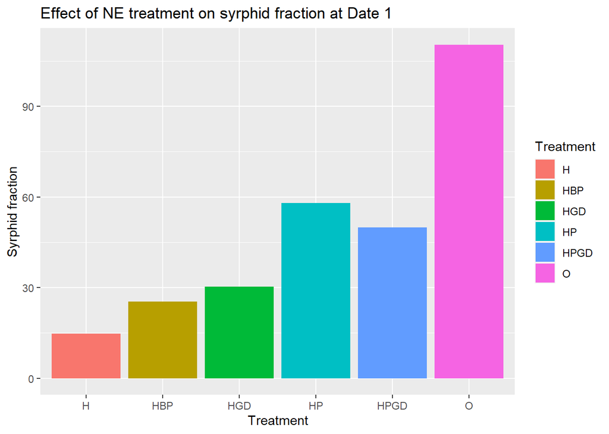

Effect of NE treatment on syrphid fraction at Date 1

```r
#barplot using Date_1
G1 <- ggplot(Date_1, aes(x= Treatment, y= syrphid_fraction, fill = Treatment))+
  geom_bar(stat="identity")+
  labs(x="Treatment", y="Syrphid fraction", title="Effect of NE treatment on syrphid fraction at Date 1")
print(G1)
```

##### **Date2**

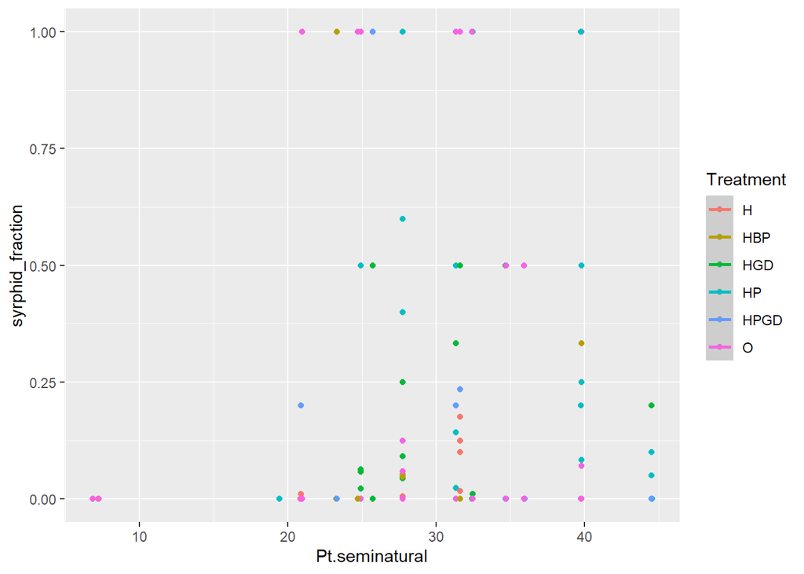

```r
# lm using Date_2
Date_2 <- Data1[Data1$Date == "2", ]
syrphid_fraction <- (Date_2$syrphidl_p /((Date_2$aphid_live)+(Date_2$syrphidl_p)))
Date_2$syrphid_fraction <- syrphid_fraction

Date2buff <- subset(Date_2, BUFF_DIST ==900)

lm1 <- lm(Date_2$syrphid_fraction ~ Date_2$Pt.seminatural)

# ggplot using Date2buff
ggplot(Date2buff, aes(x= Pt.seminatural, y= syrphid_fraction,
                      color = Treatment)) +
  geom_jitter()+
  geom_smooth(method="exp")
```

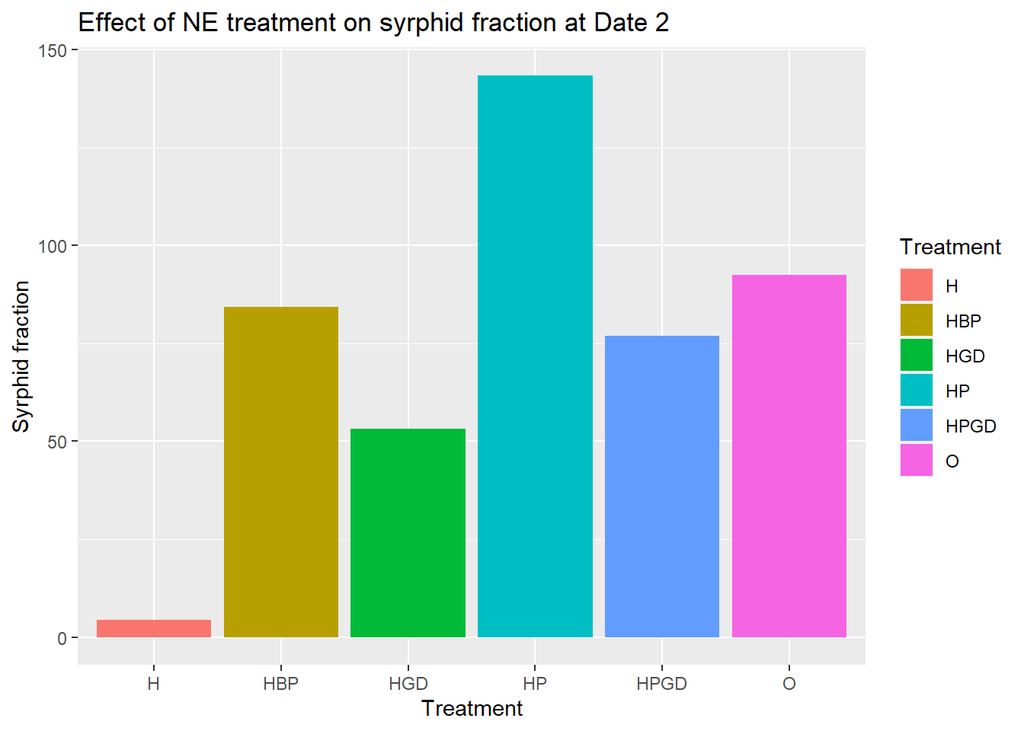

Effect of NE treatment on syrphid fraction at Date 2

```r
#barplot using Date_2
G1 <- ggplot(Date_2, aes(x= Treatment, y= syrphid_fraction, fill = Treatment))+
  geom_bar(stat="identity")+
  labs(x="Treatment", y="Syrphid fraction", title="Effect of NE treatment on syrphid fraction at Date 2")
print(G1)
```